# Sinergies between Blackwell and Electronidex

Edison Guevara

1-11-2019

# Goal and Objectives

The objective of the following report is to compare sales´ data from Blackwell together with an online company called “Electronidex” in order to determine whether there are sinergies between both companies as to support a merging between them.

# Excecutive Summary

By comparing the sales volume per product category of Electronidex with Blackwell´s and looking at the association rules found on Electronidex´s B2B transactions no significant synergies can be found. Therefore the adquisition of Electronidex is not recommended.

The reasons are the following: - The are no significant association rules found on Electronidex´s B2C transactions. On the other hand Blackwell´s clients are mainly private. - The 5 more significant association rules found on Electronidex´s B2B transactions are: * {Monitor} => {Accessories}  
* {Laptop} => {Accessories}  
* {Accessories} => {Desktop}  
* {Desktop} => {Accessories}  
* {Laptop} => {Desktop} However, Blackwell won´t benefit from increasing their sales in Accessories, since they yield the least profit. On the other hand, Electronidex´s sales of Desktops, Laptops and Monitors are much higher than Blackwell´s, which means Electronidex will be the one profiting from the associations but not Blackwell.

```r
# Loading required libraries
pacman::p_load(tidyverse, caret, readr, VIM, rstudioapi, arules, arulesViz,
               DEoptimR)
```

```r
# Importing data
# Set working directory
# current_path = getActiveDocumentContext()$path
# setwd("C:/Users/edison/Documents/Ubiqum/Data Analytics Course/Module II/Task4/")

# Electronidex transactional data

ElectronidexTrans2017_df <- read.csv("C:/Users/edison/Documents/Ubiqum/Data Analytics Course/Module II/Modul2-Task4/ElectronidexTransactions2017.csv",
                                     header = F, sep = ",", strip.white = T)

ElectronidexTrans2017 <- read.transactions("C:/Users/edison/Documents/Ubiqum/Data Analytics Course/Module II/Modul2-Task4/ElectronidexTransactions2017.csv",
                                           header = F, sep = ",",
                                           format = "basket",
                                           rm.duplicates = T)
# Product Type key file
ProductType_key <- read.csv("C:/Users/edison/Documents/Ubiqum/Data Analytics Course/Module II/Modul2-Task4/ProductType_csv.csv", header = T, sep = ";")

# Blackwell product data
existingprod <- read.csv("C:/Users/edison/Documents/Ubiqum/Data Analytics Course/Module II/Modul2-Task4/Data_BW/existingproductattributes2017.csv")

newprod <- read.csv("C:/Users/edison/Documents/Ubiqum/Data Analytics Course/Module II/Modul2-Task4/Data_BW/newprod_pred.csv", header = T, sep = ";")
```

# Pre-processing the data

```r
# Preprocessing Blackwell product data

# Adding Profit monthly to existing products
existingprod$ProfitMonthly <- existingprod$Volume * existingprod$Price *
  existingprod$ProfitMargin

# Merging existing with new products in one data frame
newprod$Volume <- NULL
colnames(newprod)[colnames(newprod) == "finalpredictedvolume"] <- "Volume"
ncol(newprod)
```

```
## [1] 19
```

```r
blackwell_prod <- rbind(existingprod, newprod)
levels(blackwell_prod$ProductType)[2] <- "Monitor"
levels(blackwell_prod$ProductType)[7] <- "Desktop"
levels(blackwell_prod$ProductType)
```

```
##  [1] "Accessories"      "Monitor"          "ExtendedWarranty"
##  [4] "GameConsole"      "Laptop"           "Netbook"
##  [7] "Desktop"          "Printer"          "PrinterSupplies"
## [10] "Smartphone"       "Software"         "Tablet"
```

# Exploring the data

```r
# Exploring the transactions file
# summary(ElectronidexTrans2017)
#inspect(head(ElectronidexTrans2017,2))
# length(ElectronidexTrans2017)

# size(ElectronidexTrans2017)
# summary(size(ElectronidexTrans2017))
# str(size(ElectronidexTrans2017))

# head(LIST(ElectronidexTrans2017),5)
```

## Electronidex figures

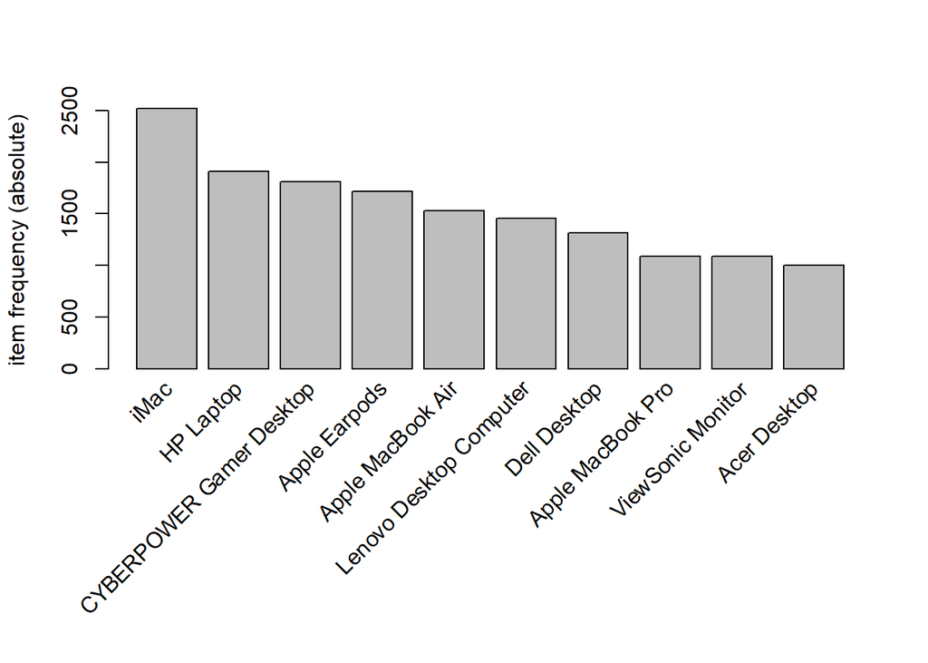

```r
itemFrequencyPlot(ElectronidexTrans2017, topN = 10, type = "absolute")
```

```r
str(ElectronidexTrans2017_df)
```

```
## 'data.frame':    9835 obs. of  32 variables:
##  $ V1 : Factor w/ 123 levels "","1TB Portable External Hard Drive",..: 7 38 71 8 65 71 36 65 87 71 ...
##  $ V2 : Factor w/ 123 levels "","1TB Portable External Hard Drive",..: 29 80 1 80 70 23 1 27 1 55 ...
##  $ V3 : Factor w/ 125 levels "","1TB Portable External Hard Drive",..: 26 19 1 71 47 80 1 35 1 1 ...
##  $ V4 : Factor w/ 122 levels "","1TB Portable External Hard Drive",..: 118 1 1 121 22 92 1 14 1 1 ...
##  $ V5 : Factor w/ 119 levels "","1TB Portable External Hard Drive",..: 1 1 1 1 1 53 1 76 1 1 ...
##  $ V6 : Factor w/ 116 levels "","1TB Portable External Hard Drive",..: 1 1 1 1 1 1 1 1 1 1 ...
##  $ V7 : Factor w/ 115 levels "","1TB Portable External Hard Drive",..: 1 1 1 1 1 1 1 1 1 1 ...
##  $ V8 : Factor w/ 114 levels "","1TB Portable External Hard Drive",..: 1 1 1 1 1 1 1 1 1 1 ...
##  $ V9 : Factor w/ 108 levels "","1TB Portable External Hard Drive",..: 1 1 1 1 1 1 1 1 1 1 ...
##  $ V10: Factor w/ 107 levels "","1TB Portable External Hard Drive",..: 1 1 1 1 1 1 1 1 1 1 ...
##  $ V11: Factor w/ 100 levels "","1TB Portable External Hard Drive",..: 1 1 1 1 1 1 1 1 1 1 ...
##  $ V12: Factor w/ 91 levels "","2TB Portable External Hard Drive",..: 1 1 1 1 1 1 1 1 1 1 ...
##  $ V13: Factor w/ 80 levels "","1TB Portable External Hard Drive",..: 1 1 1 1 1 1 1 1 1 1 ...
##  $ V14: Factor w/ 77 levels "","2TB Portable External Hard Drive",..: 1 1 1 1 1 1 1 1 1 1 ...
```

[output cut: 18 more lines]

```r
# Changing factors into char
ElectronidexTrans2017_df <- ElectronidexTrans2017_df %>%
  mutate_if(is.factor, as.character)

# Adding up Electronidex data frame to calculate sales volume
elec_volume <- data.frame(table(unlist(ElectronidexTrans2017_df)))
elec_volume <- elec_volume[-1,]
rownames(elec_volume) <- NULL
colnames(elec_volume) <- c("product_name", "volume")
elec_volume <- elec_volume[order(elec_volume$product_name),]

# Merging product type to elec_volume
checking_vector <- c()

for (i in 1:125){
  checking_vector[i] <- ProductType_key[i,1] == elec_volume[i,1]
}


Comparison_vector <- cbind(elec_volume$product_name,
                           ProductType_key$ProductName,
                           as.data.frame(checking_vector))

elec_volume$product_type <- ProductType_key$BlackWell
```

## Electronidex sales volume

### Sales volume distribution

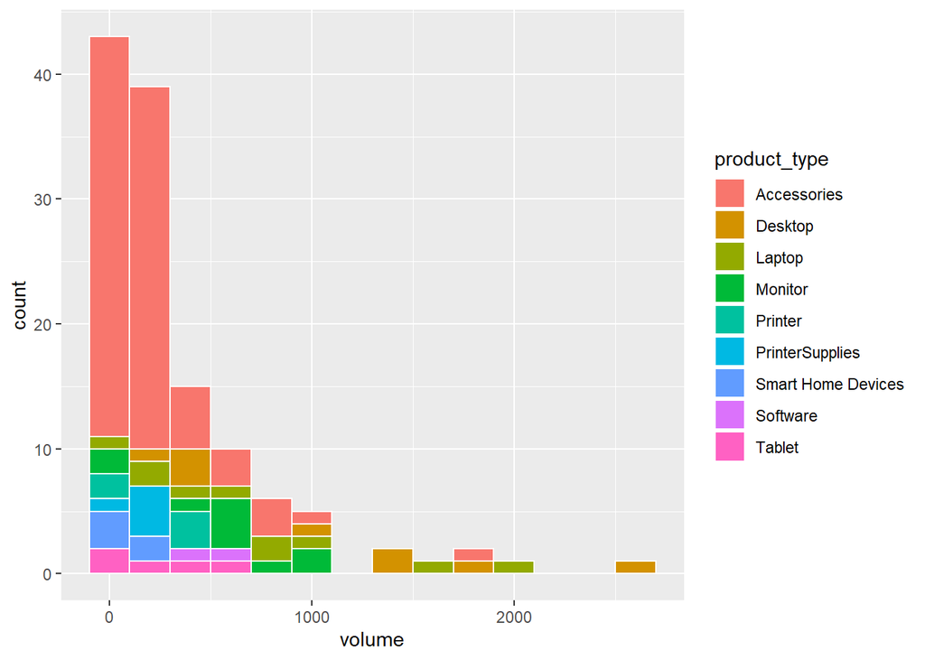

```r
ggplot(elec_volume, aes(volume, fill = product_type)) +
  geom_histogram(binwidth = 200, color ="white")
```

### Sales volume per category

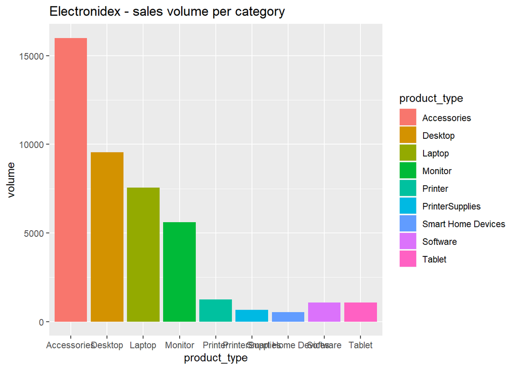

```r
ggplot(elec_volume, aes(x=product_type, y=volume, fill = product_type)) +
  geom_bar(stat = "identity") + ggtitle("Electronidex - sales volume per category")
```

# Comparison with Blackwell

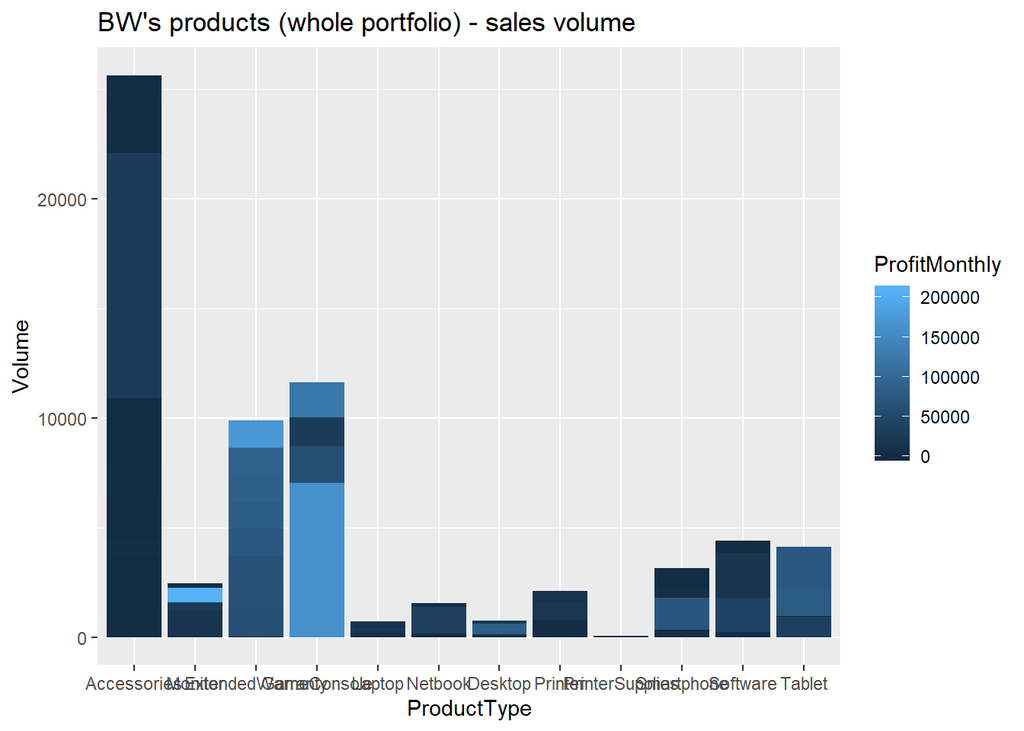

```r
# Setting category "Laptop and Netbook"

# levels(blackwell_prod$ProductType)[(levels(blackwell_prod$ProductType) ==
#                                     "Laptop")] <- "Laptop&Netbook"

# levels(blackwell_prod$ProductType)[(levels(blackwell_prod$ProductType) ==
#                                     "Netbook")] <- "Laptop&Netbook"

ggplot(blackwell_prod, aes(x = ProductType, y = Volume, fill = ProfitMonthly)) +
  geom_bar(stat = "identity") +
  ggtitle("BW's products (whole portfolio) - sales volume")
```

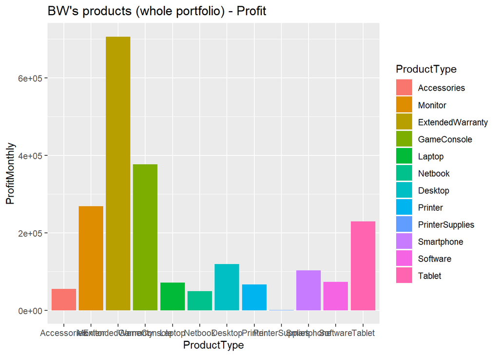

```r
ggplot(blackwell_prod, aes(x = ProductType, y = ProfitMonthly, fill =
                             ProductType)) +
  geom_bar(stat = "identity") +
  ggtitle("BW's products (whole portfolio) - Profit")
```

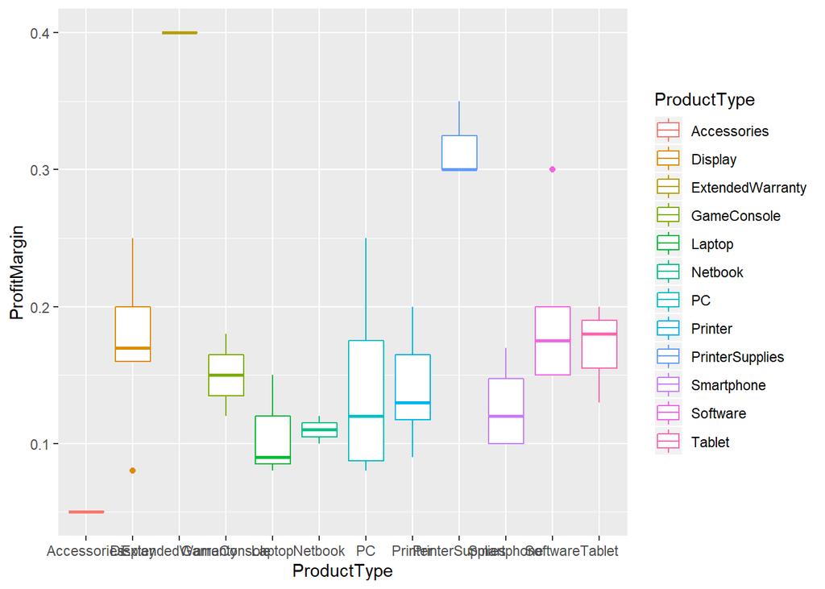

```r
ggplot(existingprod, aes(x = ProductType, y = ProfitMargin,
                         color = ProductType)) +  geom_boxplot()
```

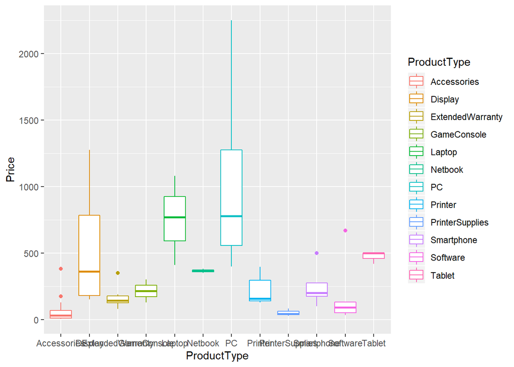

```r
ggplot(existingprod, aes(x = ProductType, y = Price,
                         color = ProductType)) +  geom_boxplot()
```

# Estimating Electronidex’s profit monthly

We will use BW’s product type price and profit margin in order to estimate Electronidex’s monthly profit. For this we will use the median of the products per category (to account for outliers).

```r
# Getting meadian for price and profit margin in BW's data
bw_price <- boxplot(existingprod$Price ~ existingprod$ProductType, plot = F)$stats[3,]

bw_profitmargin <- boxplot(existingprod$ProfitMargin ~ existingprod$ProductType, plot = F)$stats[3,]

bw_product_type <- cbind(levels(blackwell_prod$ProductType), bw_price, bw_profitmargin)

colnames(bw_product_type)[1] <- "product_type"

bw_product_type <- as.data.frame(bw_product_type)

# Creating a data frame to merge Elec?s data with estimated price and profit margin
elec_volume_profit <- merge(elec_volume, bw_product_type, by = "product_type")

elec_volume_profit$volume <- as.integer(elec_volume_profit$volume)
elec_volume_profit$bw_price <- as.numeric(elec_volume_profit$bw_price)
elec_volume_profit$bw_profitmargin <-
  as.numeric(elec_volume_profit$bw_profitmargin)

elec_volume_profit$profit <- elec_volume_profit$volume *
  elec_volume_profit$bw_price * elec_volume_profit$bw_profitmargin
```

Ploting the estimated monthly profit of Electronidex per product type.

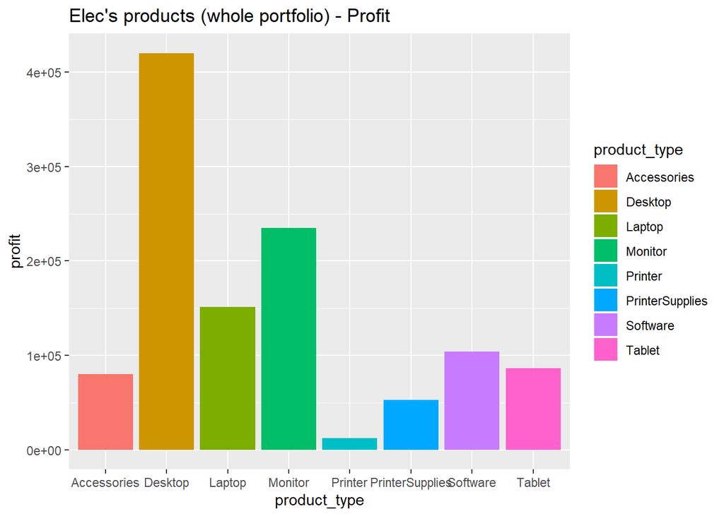

```r
ggplot(elec_volume_profit, aes(x = product_type, y = profit, fill = product_type)) +
  geom_bar(stat = "identity") +
  ggtitle("Elec's products (whole portfolio) - Profit")
```

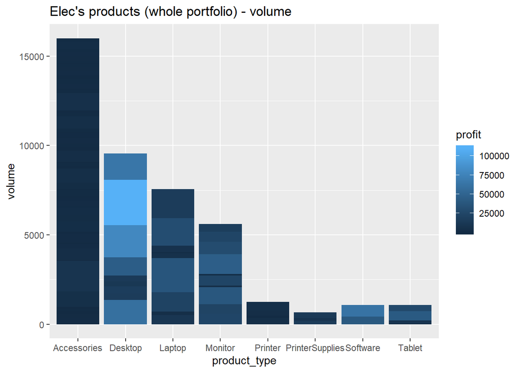

```r
ggplot(elec_volume_profit, aes(x = product_type, y = volume, fill = profit)) +
  geom_bar(stat = "identity") +
  ggtitle("Elec's products (whole portfolio) - volume")
```

```r
sum(elec_volume$volume)
```

```
## [1] 43315
```

```r
sum(blackwell_prod$Volume)
```

```
## [1] 66450.61
```

# Spliting the data

## Understanding Electronidex’s transactions

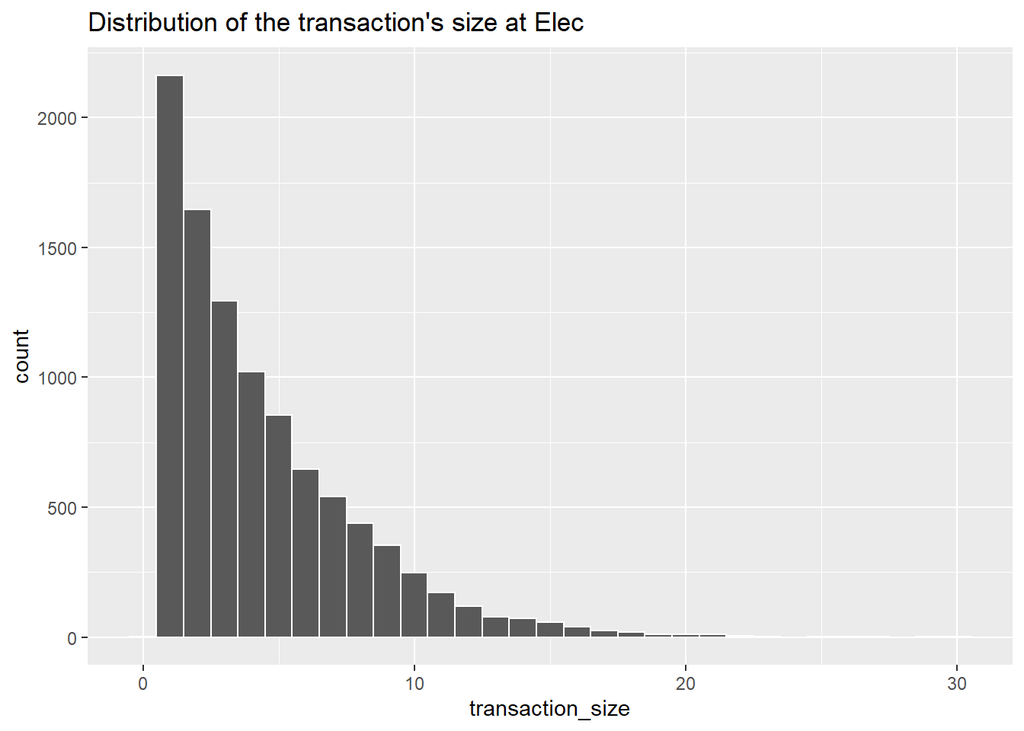

```r
dist_trans <- sort(size(ElectronidexTrans2017), decreasing = F )
dist_trans <- as.data.frame(dist_trans)
colnames(dist_trans) <- c("transaction_size")

ggplot(dist_trans, aes(x = transaction_size)) +
  geom_histogram(binwidth = 1, color = "white") +
  ggtitle("Distribution of the transaction's size at Elec")
```

```r
summary(size(ElectronidexTrans2017))
```

```
##    Min. 1st Qu.  Median    Mean 3rd Qu.    Max.
##   0.000   2.000   3.000   4.383   6.000  30.000
```

As can be seen in the previous figure, there are transactions with up to 30 different products. This situation indicates that some customers are companies (B2B transactions). On the other hand, most transactions contain up to 3 items, which indicates that most customers are private (B2C transactions). Given this situation, a split of the data is needed in order to look for specific association rules.

## Adding product type to Elec’s transactional file

In order to look for sinergies between BW and Elec only the product type will be considered. For this, the product type of BW will be used, covering all product types been sold by Elec.

```r
ElectronidexTrans2017@itemInfo$ProductType <- ProductType_key$BlackWell
```

## Splitting the data - rules

```r
itemfreq_df <- as.data.frame(itemFrequency(ElectronidexTrans2017, type = "absolute"))
itemfreq_df["iMac",1]
```

```
## [1] 2519
```

```r
inspect(head(ElectronidexTrans2017[size(ElectronidexTrans2017) > 5], 5))
```

```
##     items
## [1] {Acer Aspire,
##      Apple MacBook Pro,
##      ASUS 2 Monitor,
##      ASUS Monitor,
##      Dell Desktop,
##      iMac,
##      JBL Splashproof Portable Bluetooth Speaker,
##      Lenovo Desktop Computer,
##      Rii LED Gaming Keyboard & Mouse Combo}
## [2] {1TB Portable External Hard Drive,
##      CYBERPOWER Gamer Desktop,
##      Dell Desktop,
##      Fire TV Stick,
##      HP Laptop,
##      iPad,
##      Logitech Keyboard,
##      Rii LED Gaming Keyboard & Mouse Combo,
##      Slim Wireless Mouse,
##      ViewSonic Monitor,
##      Wireless Portable Mouse}
## [3] {Apple Earpods,
##      Apple MacBook Air,
##      Backlit LED Gaming Keyboard,
##      HP Monitor,
##      Logitech 3-button Mouse,
##      Microsoft Wireless Desktop Keyboard and Mouse}
## [4] {Apple MacBook Pro,
##      Brother Printer,
##      CYBERPOWER Gamer Desktop,
##      Eluktronics Pro Gaming Laptop,
##      HP Laptop,
##      HP Notebook Touchscreen Laptop PC,
##      iPad Pro}
## [5] {Apple Earpods,
##      Apple Magic Keyboard,
##      Dell 2 Desktop,
##      Gaming Mouse Professional,
##      HP Laptop,
##      iMac,
##      LG Monitor,
##      Microsoft Office Home and Student 2016}
```

```r
# Finding the indices of transactions with 3 or more desktops (ind)
Desktop <- ElectronidexTrans2017@itemInfo[which(ProductType_key$BlackWell ==
                                                  "Desktop"), 1]

ind <- c()
counter <- 0
for (i in 1:9){
  for (j in (1:9)[-i]){
    for (k in (1:9)[-c(i,j)]){
      ind <- c(ind, which(ElectronidexTrans2017 %in% Desktop[i] &
               ElectronidexTrans2017 %in% Desktop[j] &
               ElectronidexTrans2017 %in% Desktop[k]))
      counter <- counter + 1
    }
  }
}
ind <- unique(ind)

# Finding the indices of transactions with 3 or more laptops (ind4)
Laptop <- ElectronidexTrans2017@itemInfo[which(ProductType_key$BlackWell ==
                                                  "Laptop"), 1]
ind4 <- c()
counter <- 0
for (i in 1:10){
  for (j in (1:10)[-i]){
    for (k in (1:10)[-c(i,j)]){
      ind4 <- c(ind4, which(ElectronidexTrans2017 %in% Laptop[i] &
               ElectronidexTrans2017 %in% Laptop[j] &
               ElectronidexTrans2017 %in% Laptop[k]))
      counter <- counter + 1
    }
  }
}

ind4 <- unique(ind4)

# Finding the indices of transactions higher than 4 items (ind2)
ind2 <- which(size(ElectronidexTrans2017) > 4)
ind2 <- unique(ind2)

# Consolidating the indices (ind_t)

ind_t <- c(ind, ind2, ind4)
ind_t <- unique(ind_t)

ElectronidexTrans2017_B2B <- ElectronidexTrans2017[ind_t]

ElectronidexTrans2017_B2C <- ElectronidexTrans2017[-ind_t]

ElectronidexTrans2017_B2B
## transactions in sparse format with
##  3778 transactions (rows) and
##  125 items (columns)
ElectronidexTrans2017_B2C
## transactions in sparse format with
##  6057 transactions (rows) and
##  125 items (columns)
inspect(head(ElectronidexTrans2017_B2B[size(ElectronidexTrans2017_B2B) < 5], 5))
```

```
##     items
## [1] {Acer Aspire,
##      Acer Desktop,
##      ASUS Desktop,
##      Dell Desktop}
## [2] {Acer Desktop,
##      CYBERPOWER Gamer Desktop,
##      Dell Desktop}
## [3] {Acer Desktop,
##      Acer Monitor,
##      CYBERPOWER Gamer Desktop,
##      iMac}
## [4] {Acer Desktop,
##      CYBERPOWER Gamer Desktop,
##      iMac,
##      Logitech MK270 Wireless Keyboard and Mouse Combo}
## [5] {Acer Desktop,
##      Alienware Laptop,
##      CYBERPOWER Gamer Desktop,
##      Intel Desktop}
```

```r
inspect(head(ElectronidexTrans2017_B2C[size(ElectronidexTrans2017_B2C) < 5], 5))
```

```
##     items
## [1] {Acer Aspire,
##      Belkin Mouse Pad,
##      Brother Printer Toner,
##      VGA Monitor Cable}
## [2] {Apple Wireless Keyboard,
##      Dell Desktop,
##      Lenovo Desktop Computer}
## [3] {iMac}
## [4] {ASUS Desktop,
##      Epson Black Ink,
##      HP Laptop,
##      iMac}
## [5] {CYBERPOWER Gamer Desktop}
```

The final split of transactions is as follows:

- B2B: 3778 transactions
  - 3 or more desktops
  - 3 or more laptops
  - more than 4 items baught
- B2C: 6057 transactions

# Association rules

## Association rules for B2C

```r
ElectronidexTrans2017_B2C_pt <- arules::aggregate(ElectronidexTrans2017_B2C,
                                                by = "ProductType")

association_rules_b2c_pt <- apriori(ElectronidexTrans2017_B2C_pt,
                             parameter = list(supp = 0.005, conf = 0.8,
                                              minlen = 2))
## Apriori
##
## Parameter specification:
##  confidence minval smax arem  aval originalSupport maxtime support minlen
##         0.8    0.1    1 none FALSE            TRUE       5   0.005      2
##  maxlen target   ext
##      10  rules FALSE
##
## Algorithmic control:
##  filter tree heap memopt load sort verbose
##     0.1 TRUE TRUE  FALSE TRUE    2    TRUE
##
## Absolute minimum support count: 30
##
## set item appearances ...[0 item(s)] done [0.00s].
## set transactions ...[9 item(s), 6057 transaction(s)] done [0.00s].
## sorting and recoding items ... [9 item(s)] done [0.00s].
## creating transaction tree ... done [0.00s].
## checking subsets of size 1 2 3 4 done [0.00s].
## writing ... [0 rule(s)] done [0.00s].
## creating S4 object  ... done [0.00s].

ElectronidexTrans2017_pt <- arules::aggregate(ElectronidexTrans2017,
                                                by = "ProductType")

association_rules_pt <- apriori(ElectronidexTrans2017_pt,
                             parameter = list(supp = 0.0001, conf = 0.8,
                                              minlen = 2))
## Apriori
##
## Parameter specification:
##  confidence minval smax arem  aval originalSupport maxtime support minlen
##         0.8    0.1    1 none FALSE            TRUE       5   1e-04      2
##  maxlen target   ext
##      10  rules FALSE
##
## Algorithmic control:
##  filter tree heap memopt load sort verbose
##     0.1 TRUE TRUE  FALSE TRUE    2    TRUE
##
## Absolute minimum support count: 0
##
## set item appearances ...[0 item(s)] done [0.00s].
## set transactions ...[9 item(s), 9835 transaction(s)] done [0.00s].
## sorting and recoding items ... [9 item(s)] done [0.00s].
## creating transaction tree ... done [0.00s].
## checking subsets of size 1 2 3 4 5 6 7 8 9 done [0.00s].
## writing ... [697 rule(s)] done [0.00s].
## creating S4 object  ... done [0.00s].

head(inspect(sort(association_rules_b2c_pt, by = "lift")),5)
## NULL
```

## Association rules for B2B

```r
ElectronidexTrans2017_B2B_pt <- arules::aggregate(ElectronidexTrans2017_B2B,
                                                by = "ProductType")

association_rules_b2b_pt <- apriori(ElectronidexTrans2017_B2B_pt,
                             parameter = list(supp = 0.6, conf = 0.8,
                                              minlen = 2))
## Apriori
##
## Parameter specification:
##  confidence minval smax arem  aval originalSupport maxtime support minlen
##         0.8    0.1    1 none FALSE            TRUE       5     0.6      2
##  maxlen target   ext
##      10  rules FALSE
##
## Algorithmic control:
##  filter tree heap memopt load sort verbose
##     0.1 TRUE TRUE  FALSE TRUE    2    TRUE
##
## Absolute minimum support count: 2266
##
## set item appearances ...[0 item(s)] done [0.00s].
## set transactions ...[9 item(s), 3778 transaction(s)] done [0.00s].
## sorting and recoding items ... [4 item(s)] done [0.00s].
## creating transaction tree ... done [0.00s].
## checking subsets of size 1 2 3 done [0.00s].
## writing ... [5 rule(s)] done [0.00s].
## creating S4 object  ... done [0.00s].

head(inspect(sort(association_rules_b2b_pt, by = "lift")),5)
```

```
##     lhs              rhs           support   confidence lift      count
## [1] {Monitor}     => {Accessories} 0.6429328 0.9503130  1.0048370 2429
## [2] {Laptop}      => {Accessories} 0.7114876 0.9438202  0.9979717 2688
## [3] {Accessories} => {Desktop}     0.8012176 0.8471872  0.9964737 3027
## [4] {Desktop}     => {Accessories} 0.8012176 0.9424035  0.9964737 3027
## [5] {Laptop}      => {Desktop}     0.6355214 0.8430478  0.9916047 2401
##               lhs              rhs   support confidence      lift count
## [1]     {Monitor} => {Accessories} 0.6429328  0.9503130 1.0048370  2429
## [2]      {Laptop} => {Accessories} 0.7114876  0.9438202 0.9979717  2688
## [3] {Accessories} =>     {Desktop} 0.8012176  0.8471872 0.9964737  3027
## [4]     {Desktop} => {Accessories} 0.8012176  0.9424035 0.9964737  3027
## [5]      {Laptop} =>     {Desktop} 0.6355214  0.8430478 0.9916047  2401
```

[1] {Monitor} => {Accessories}  
[2] {Laptop} => {Accessories}  
[3] {Accessories} => {Desktop}  
[4] {Desktop} => {Accessories}  
[5] {Laptop} => {Desktop}

# Association rules including gaming products

```r
association_rules_b2b <- apriori(ElectronidexTrans2017_B2B,
                             parameter = list(supp = 0.008, conf = 0.8,
                                              minlen = 2))
## Apriori
##
## Parameter specification:
##  confidence minval smax arem  aval originalSupport maxtime support minlen
##         0.8    0.1    1 none FALSE            TRUE       5   0.008      2
##  maxlen target   ext
##      10  rules FALSE
##
## Algorithmic control:
##  filter tree heap memopt load sort verbose
##     0.1 TRUE TRUE  FALSE TRUE    2    TRUE
##
## Absolute minimum support count: 30
##
## set item appearances ...[0 item(s)] done [0.00s].
## set transactions ...[125 item(s), 3778 transaction(s)] done [0.00s].
## sorting and recoding items ... [110 item(s)] done [0.00s].
## creating transaction tree ... done [0.00s].
## checking subsets of size 1 2 3 4 5 done [0.00s].
## writing ... [4 rule(s)] done [0.00s].
## creating S4 object  ... done [0.00s].

head(inspect(sort(association_rules_b2b, by = "lift")),5)
```

```
##     lhs                                         rhs             support confidence     lift count
## [1] {Acer Aspire,
##      Dell Desktop,
##      iMac,
##      ViewSonic Monitor}                      => {HP Laptop} 0.009793542   0.902439 2.451053    37
## [2] {Acer Aspire,
##      Dell Desktop,
##      ViewSonic Monitor}                      => {HP Laptop} 0.013763896   0.812500 2.206776    52
## [3] {Acer Desktop,
##      Dell Desktop,
##      iMac,
##      ViewSonic Monitor}                      => {HP Laptop} 0.008470090   0.800000 2.172825    32
## [4] {Dell Desktop,
##      Microsoft Office Home and Student 2016,
##      ViewSonic Monitor}                      => {iMac}      0.008734780   0.804878 1.807865    33
## NULL
```

# Annex

## Blackwell - comparison current vs new products

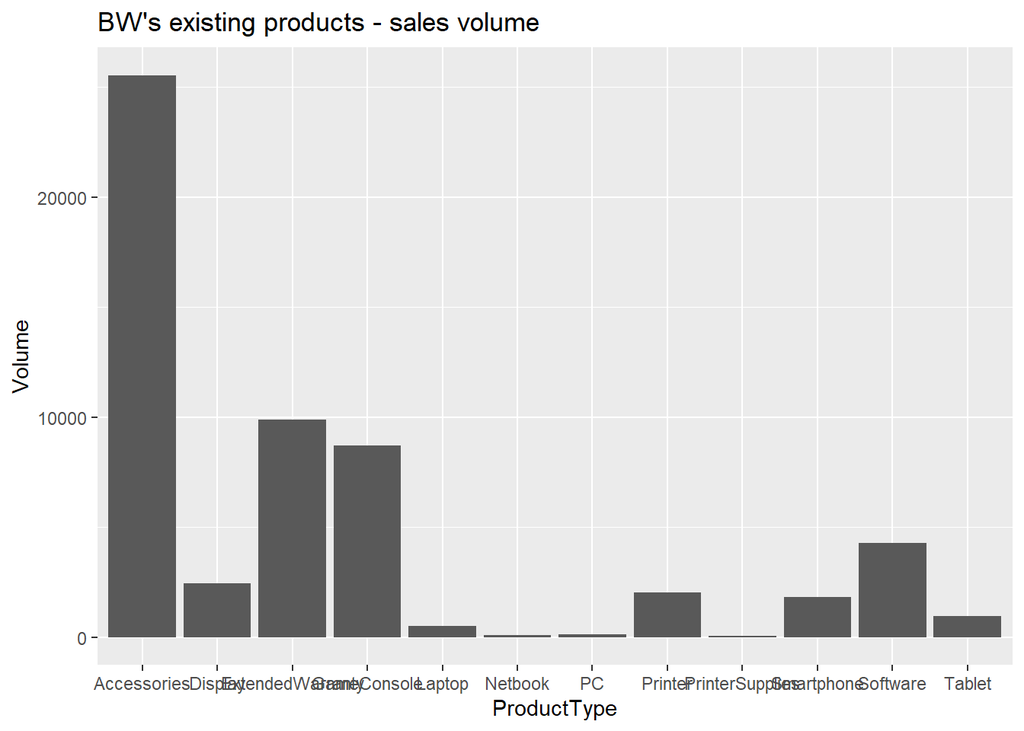

```r
ggplot(existingprod, aes(x = ProductType, y = Volume)) +
  geom_bar(stat = "identity") +
  ggtitle("BW's existing products - sales volume")
```

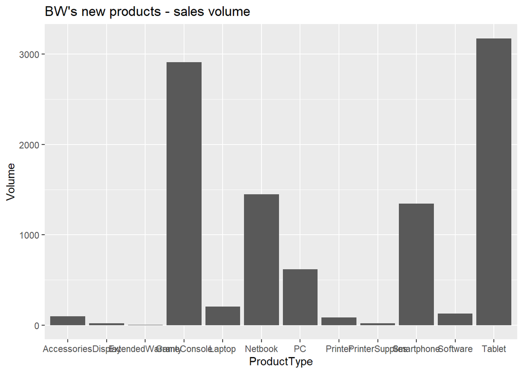

```r
ggplot(newprod, aes(x = ProductType, y = Volume)) +
  geom_bar(stat = "identity") +
  ggtitle("BW's new products - sales volume")
```

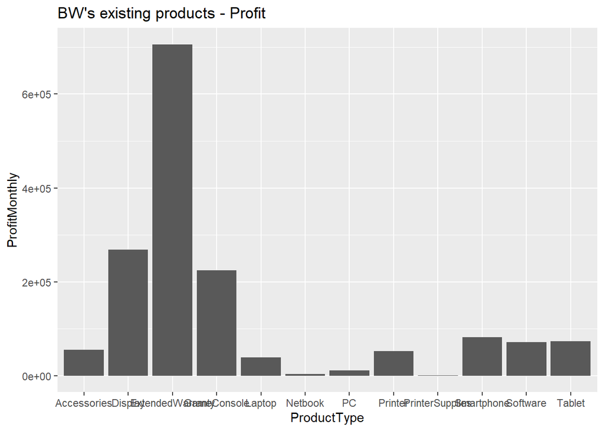

```r
ggplot(existingprod, aes(x = ProductType, y = ProfitMonthly)) +
  geom_bar(stat = "identity") +
  ggtitle("BW's existing products - Profit")
```

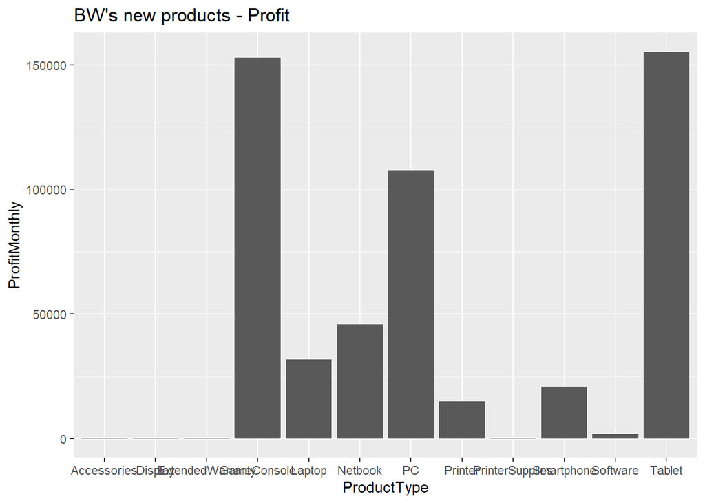

```r
ggplot(newprod, aes(x = ProductType, y = ProfitMonthly)) +
  geom_bar(stat = "identity") +
  ggtitle("BW's new products - Profit")
```